# Лабораторная работа №4

Операционные системы

Малюга В. В.

Российский университет дружбы народов, Москва, Россия

9 марта 2024

## Цель работы

Получение навыков правильной работы с репозиториями git.

## Задание

1. Выполнить работу для тестового репозитория.
2. Преобразовать рабочий репозиторий в репозиторий с git-flow и conventional commits.

## Выполнение лабораторной работы. Установка git-flow

Установка git flow из коллекции репозиториев Copr (рис. 1).

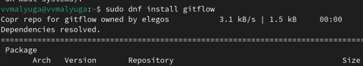

Установка

## Выполнение лабораторной работы. Установка Node.js

Установила nodejs и pnpm (рис. 2).

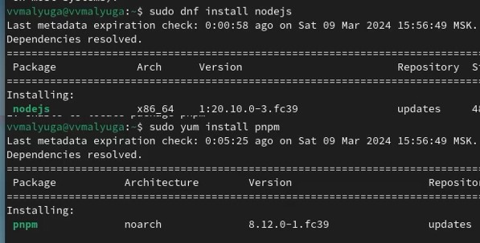

Установка

## Выполнение лабораторной работы. Настройка Node.js

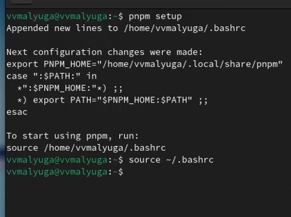

Настройка

## Выполнение лабораторной работы. Общепринятые коммиты

Запустила программы, которые используются для помощи в форматировании коммитов и в создании логов (рис. 4).

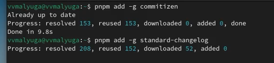

Настройка

## Выполнение лабораторной работы. Общепринятые коммиты

Создала репозиторий, сделала первый коммит и загрузила на гитхаб. Далее заполняю параметры пакета (рис. 5).

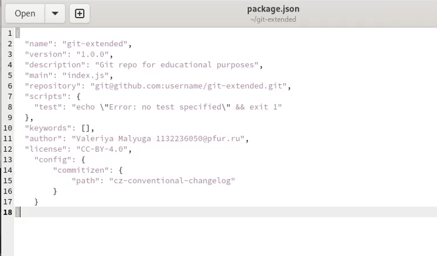

Заполнение параметров пакета

## Выполнение лабораторной работы. Общепринятые коммиты

Добавила новые файлы, выполнила коммит, отправила на гитхаб (рис. 6).

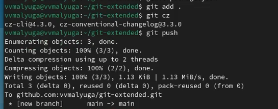

Отправка новых файлов на гитхаб

## Выполнение лабораторной работы. Общепринятые коммиты

Инициализировала git-flow. Префикс для ярлыков установила v. Загрузила весь репозиторий в хранилище. Установила внешнюю ветку как вышестоящую для этой ветки. Создала релиз с версией 1.0.0. Создала журнал изменений (рис. 7).

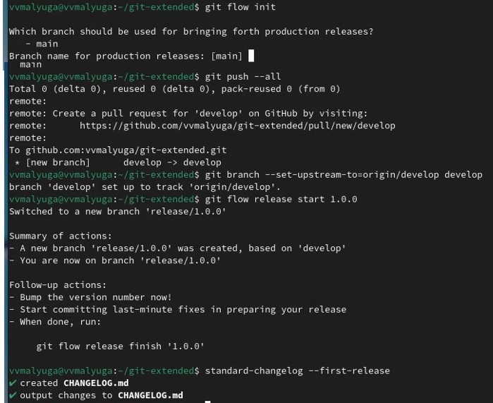

Конфигурация git-flow

## Выполнение лабораторной работы. Общепринятые коммиты

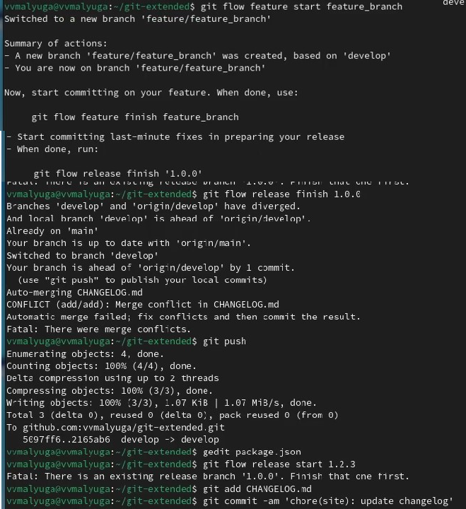

Конфигурация git-flow

## Выводы

Получила навыки правильной работы с репозиториями git.